# Customer Lifetime Value (CLV) Modeling with Linear Regression - OLS and Bayesian

## Load and inspect data

```r
#browseURL("https://archive.ics.uci.edu/ml/datasets/Online+Retail+II")
```

**Data Set Information:**

This Online Retail II data set contains all the transactions occurring for a UK-based and registered, non-store online retail between 01/12/2009 and 09/12/2011.The company mainly sells unique all-occasion gift-ware. Many customers of the company are wholesalers.

**Attribute Information:**

**InvoiceNo:** Invoice number. Nominal. A 6-digit integral number uniquely assigned to each transaction. If this code starts with the letter ‘c’, it indicates a cancellation.

**StockCode:** Product (item) code. Nominal. A 5-digit integral number uniquely assigned to each distinct product.

Description: Product (item) name. Nominal.

**Quantity:** The quantities of each product (item) per transaction. Numeric.

**InvoiceDate:** Invoice date and time. Numeric. The day and time when a transaction was generated.

**UnitPrice:** Unit price. Numeric.Product price per unit in sterling (£).

**CustomerID:** Customer number. Nominal. A 5-digit integral number uniquely assigned to each customer.

**Country:** Country name. Nominal. The name of the country where a customer resides.

```r
# Install pacman if needed
if (!require("pacman")) install.packages("pacman")
# load packages
pacman::p_load(pacman,
  tidyverse, rpart, psych, corrplot, cowplot, tree, VIM, GGally, lubridate, car)
```

```r
#import file
dataset_2009 <- read.csv("datasets/online_retail_2009.csv")

head(dataset_2009) #check results
```

|  | Invoice | StockCode | Description | Quantity | InvoiceDate | Price | Customer.ID | Country |
| --- | --- | --- | --- | --- | --- | --- | --- | --- |
| 1 | 489434 | 85048 | 15CM CHRISTMAS GLASS BALL 20 LIGHTS | 12 | 12/1/09 7:45 | 6.95 | 13085 | United Kingdom |
| 2 | 489434 | 79323P | PINK CHERRY LIGHTS | 12 | 12/1/09 7:45 | 6.75 | 13085 | United Kingdom |
| 3 | 489434 | 79323W | WHITE CHERRY LIGHTS | 12 | 12/1/09 7:45 | 6.75 | 13085 | United Kingdom |
| 4 | 489434 | 22041 | RECORD FRAME 7" SINGLE SIZE | 48 | 12/1/09 7:45 | 2.10 | 13085 | United Kingdom |
| 5 | 489434 | 21232 | STRAWBERRY CERAMIC TRINKET BOX | 24 | 12/1/09 7:45 | 1.25 | 13085 | United Kingdom |
| 6 | 489434 | 22064 | PINK DOUGHNUT TRINKET POT | 24 | 12/1/09 7:45 | 1.65 | 13085 | United Kingdom |

```r
dataset_2010 <- read.csv("datasets/online_retail_2010.csv")
head(dataset_2010) #check results
```

|  | Invoice | StockCode | Description | Quantity | InvoiceDate | Price | Customer.ID | Country |
| --- | --- | --- | --- | --- | --- | --- | --- | --- |
| 1 | 536365 | 85123A | WHITE HANGING HEART T-LIGHT HOLDER | 6 | 12/1/10 8:26 | 2.55 | 17850 | United Kingdom |
| 2 | 536365 | 71053 | WHITE METAL LANTERN | 6 | 12/1/10 8:26 | 3.39 | 17850 | United Kingdom |
| 3 | 536365 | 84406B | CREAM CUPID HEARTS COAT HANGER | 8 | 12/1/10 8:26 | 2.75 | 17850 | United Kingdom |
| 4 | 536365 | 84029G | KNITTED UNION FLAG HOT WATER BOTTLE | 6 | 12/1/10 8:26 | 3.39 | 17850 | United Kingdom |
| 5 | 536365 | 84029E | RED WOOLLY HOTTIE WHITE HEART. | 6 | 12/1/10 8:26 | 3.39 | 17850 | United Kingdom |
| 6 | 536365 | 22752 | SET 7 BABUSHKA NESTING BOXES | 2 | 12/1/10 8:26 | 7.65 | 17850 | United Kingdom |

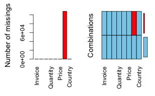

```r
#any missing data? Using aggr function from VIM package
aggr(dataset_2009, prop = F, numbers = T) # no red - no missing values
```

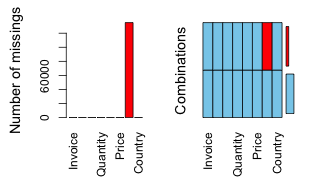

```r
aggr(dataset_2010, prop = F, numbers = T) # no red - no missing values
```

Some customerID’s are missing.

```r
df_combined <- rbind(dataset_2009, dataset_2010)

dim(df_combined)
```

```
[1] 1067371       8
```

```r
(df_summary_stats <- df_combined %>%
  summary())
```

```
   Invoice           StockCode         Description           Quantity         InvoiceDate
 Length:1067371     Length:1067371     Length:1067371     Min.   :-80995.00   Length:1067371
 Class :character   Class :character   Class :character   1st Qu.:     1.00   Class :character
 Mode  :character   Mode  :character   Mode  :character   Median :     3.00   Mode  :character
                                                          Mean   :     9.94
                                                          3rd Qu.:    10.00
                                                          Max.   : 80995.00

     Price            Customer.ID       Country
 Min.   :-53594.36   Min.   :12346    Length:1067371
 1st Qu.:     1.25   1st Qu.:13975    Class :character
 Median :     2.10   Median :15255    Mode  :character
 Mean   :     4.65   Mean   :15325
 3rd Qu.:     4.15   3rd Qu.:16797
 Max.   : 38970.00   Max.   :18287
                     NA's   :243007
```

1067371 total rows. Lots of negative values for quantity and price. These rows will need to be removed.

```r
df <- df_combined %>%
  filter(Quantity > 0) %>%
  filter(Price > 0) %>%
  filter(Customer.ID != "NA") %>%
  filter(!grepl("TEST", StockCode))

dim(df)
```

```
[1] 805539      8
```

Removed negative orders and now have 805,539 rows of data

```r
str(df$InvoiceDate)
```

```
 chr [1:805539] "12/1/09 7:45" "12/1/09 7:45" "12/1/09 7:45" "12/1/09 7:45" "12/1/09 7:45" ...
```

```r
#Date is character type, but needs to be date type

#Get summary stats on date column
df %>%
  select(InvoiceDate) %>%
  summarize_all(funs(min, max))
```

| min | max |
| --- | --- |
| 1/10/10 10:26 | 9/9/11 9:52 |

```r
#Convert to date type - this works swimmingly!
df$InvoiceDate <- lubridate::mdy_hm(df$InvoiceDate)

#check results
str(df$InvoiceDate)
```

```
 POSIXct[1:805539], format: "2009-12-01 07:45:00" "2009-12-01 07:45:00" "2009-12-01 07:45:00" "2009-12-01 07:45:00" ...
```

```r
#We will use the most recent purchase date in the data as our time_now variable
df <- df %>%
  mutate(time_now = max(df$InvoiceDate))

#check results
str(df$time_now)
```

```
 POSIXct[1:805539], format: "2011-12-09 12:50:00" "2011-12-09 12:50:00" "2011-12-09 12:50:00" "2011-12-09 12:50:00" ...
```

```r
# df <- df %>%
#   mutate(days_since = as.numeric(InvoiceDate - time_now),
#          purchase_amount = Quantity * Price)

df_01 <- df %>%
  mutate(days_since = round(as.numeric(difftime(time_now, InvoiceDate, units = "days"))),
         purchase_amount = Quantity * Price)

str(df_01$days_since)
```

```
 num [1:805539] 738 738 738 738 738 738 738 738 738 738 ...
```

```r
str(df_01$purchase_amount)
```

```
 num [1:805539] 83.4 81 81 100.8 30 ...
```

```r
head(df_01)
```

|  | Invoice | StockCode | Description | Quantity | InvoiceDate | Price | Customer.ID | Country | time_now | days_since | purchase_amount |
| --- | --- | --- | --- | --- | --- | --- | --- | --- | --- | --- | --- |
| 1 | 489434 | 85048 | 15CM CHRISTMAS GLASS BALL 20 LIGHTS | 12 | 2009-12-01 07:45:00 | 6.95 | 13085 | United Kingdom | 2011-12-09 12:50:00 | 738 | 83.4 |
| 2 | 489434 | 79323P | PINK CHERRY LIGHTS | 12 | 2009-12-01 07:45:00 | 6.75 | 13085 | United Kingdom | 2011-12-09 12:50:00 | 738 | 81.0 |
| 3 | 489434 | 79323W | WHITE CHERRY LIGHTS | 12 | 2009-12-01 07:45:00 | 6.75 | 13085 | United Kingdom | 2011-12-09 12:50:00 | 738 | 81.0 |
| 4 | 489434 | 22041 | RECORD FRAME 7" SINGLE SIZE | 48 | 2009-12-01 07:45:00 | 2.10 | 13085 | United Kingdom | 2011-12-09 12:50:00 | 738 | 100.8 |
| 5 | 489434 | 21232 | STRAWBERRY CERAMIC TRINKET BOX | 24 | 2009-12-01 07:45:00 | 1.25 | 13085 | United Kingdom | 2011-12-09 12:50:00 | 738 | 30.0 |
| 6 | 489434 | 22064 | PINK DOUGHNUT TRINKET POT | 24 | 2009-12-01 07:45:00 | 1.65 | 13085 | United Kingdom | 2011-12-09 12:50:00 | 738 | 39.6 |

```r
#This will make our data manipulation easier
df_02 <- df_01 %>%
  rename(
    customer_id = Customer.ID,
    stock_code = StockCode,
    invoice_date = InvoiceDate
  )

names(df_02)
```

```
 [1] "Invoice"         "stock_code"      "Description"     "Quantity"        "invoice_date"
 [6] "Price"           "customer_id"     "Country"         "time_now"        "days_since"
[11] "purchase_amount"
```

## Customer Lifetime Value (CLV) Modeling with Linear Regression (OLS)

```r
#load zoo library
library(zoo)
#We will use df_02
head(df_02)
```

|  | Invoice | stock_code | Description | Quantity | invoice_date | Price | customer_id | Country | time_now | days_since | purchase_amount |
| --- | --- | --- | --- | --- | --- | --- | --- | --- | --- | --- | --- |
| 1 | 489434 | 85048 | 15CM CHRISTMAS GLASS BALL 20 LIGHTS | 12 | 2009-12-01 07:45:00 | 6.95 | 13085 | United Kingdom | 2011-12-09 12:50:00 | 738 | 83.4 |
| 2 | 489434 | 79323P | PINK CHERRY LIGHTS | 12 | 2009-12-01 07:45:00 | 6.75 | 13085 | United Kingdom | 2011-12-09 12:50:00 | 738 | 81.0 |
| 3 | 489434 | 79323W | WHITE CHERRY LIGHTS | 12 | 2009-12-01 07:45:00 | 6.75 | 13085 | United Kingdom | 2011-12-09 12:50:00 | 738 | 81.0 |
| 4 | 489434 | 22041 | RECORD FRAME 7" SINGLE SIZE | 48 | 2009-12-01 07:45:00 | 2.10 | 13085 | United Kingdom | 2011-12-09 12:50:00 | 738 | 100.8 |
| 5 | 489434 | 21232 | STRAWBERRY CERAMIC TRINKET BOX | 24 | 2009-12-01 07:45:00 | 1.25 | 13085 | United Kingdom | 2011-12-09 12:50:00 | 738 | 30.0 |
| 6 | 489434 | 22064 | PINK DOUGHNUT TRINKET POT | 24 | 2009-12-01 07:45:00 | 1.65 | 13085 | United Kingdom | 2011-12-09 12:50:00 | 738 | 39.6 |

```r
#We need to add a quarter & month column to dataframe from our invoice_date
df_03 <- df_02%>%
  mutate(year_quarter = as.yearqtr(invoice_date, format = "%Y-%m-%d"),
year_month = as.yearmon(invoice_date))

#check results
head(df_03)
```

|  | Invoice | stock_code | Description | Quantity | invoice_date | Price | customer_id | Country | time_now | days_since | purchase_amount | year_quarter | year_month |
| --- | --- | --- | --- | --- | --- | --- | --- | --- | --- | --- | --- | --- | --- |
| 1 | 489434 | 85048 | 15CM CHRISTMAS GLASS BALL 20 LIGHTS | 12 | 2009-12-01 07:45:00 | 6.95 | 13085 | United Kingdom | 2011-12-09 12:50:00 | 738 | 83.4 | 2009 Q4 | Dec 2009 |
| 2 | 489434 | 79323P | PINK CHERRY LIGHTS | 12 | 2009-12-01 07:45:00 | 6.75 | 13085 | United Kingdom | 2011-12-09 12:50:00 | 738 | 81.0 | 2009 Q4 | Dec 2009 |
| 3 | 489434 | 79323W | WHITE CHERRY LIGHTS | 12 | 2009-12-01 07:45:00 | 6.75 | 13085 | United Kingdom | 2011-12-09 12:50:00 | 738 | 81.0 | 2009 Q4 | Dec 2009 |
| 4 | 489434 | 22041 | RECORD FRAME 7" SINGLE SIZE | 48 | 2009-12-01 07:45:00 | 2.10 | 13085 | United Kingdom | 2011-12-09 12:50:00 | 738 | 100.8 | 2009 Q4 | Dec 2009 |
| 5 | 489434 | 21232 | STRAWBERRY CERAMIC TRINKET BOX | 24 | 2009-12-01 07:45:00 | 1.25 | 13085 | United Kingdom | 2011-12-09 12:50:00 | 738 | 30.0 | 2009 Q4 | Dec 2009 |
| 6 | 489434 | 22064 | PINK DOUGHNUT TRINKET POT | 24 | 2009-12-01 07:45:00 | 1.65 | 13085 | United Kingdom | 2011-12-09 12:50:00 | 738 | 39.6 | 2009 Q4 | Dec 2009 |

```r
#Get summary stats on year_quarter column
df_03 %>%
  select(year_quarter) %>%
  summarize_all(funs(min, max))
```

| min | max |
| --- | --- |
| 2009 Q4 | 2011 Q4 |

```r
#Get summary stats on year_month column
df_03 %>%
  select(year_month) %>%
  summarize_all(funs(min, max))
```

| min | max |
| --- | --- |
| Dec 2009 | Dec 2011 |

```r
NA
```

```r
#filter on most recent customers only
#We don't have a full 3 months of data for the 4th quarter of 2011 so we need to expand it to include 3 months

#Testing the date filter logic to use in the next step
as.Date(max(df_03$invoice_date)) - 90
```

```
[1] "2011-09-10"
```

```r
df_filtered <- df_03 %>%
filter(invoice_date  >= as.Date(max(df_03$invoice_date)) - 90)

#check results
glimpse(df_filtered)
```

```
Rows: 161,527
Columns: 13
$ Invoice         <chr> "566225", "566225", "566225", "566225", "566225", "566225", "566225", "56622…
$ stock_code      <chr> "22384", "20725", "23169", "84029E", "21479", "82484", "21976", "84992", "84…
$ Description     <chr> "LUNCH BAG PINK POLKADOT", "LUNCH BAG RED RETROSPOT", "CLASSIC GLASS COOKIE …
$ Quantity        <int> 6, 6, 3, 3, 3, 2, 1, 1, 1, 1, 3, 6, 4, 2, 12, 1, 3, 4, 4, 4, 6, 6, 100, 100,…
$ invoice_date    <dttm> 2011-09-11 10:35:00, 2011-09-11 10:35:00, 2011-09-11 10:35:00, 2011-09-11 1…
$ Price           <dbl> 1.65, 1.65, 4.15, 4.25, 4.25, 7.95, 0.55, 0.55, 0.55, 0.55, 0.75, 2.95, 3.75…
$ customer_id     <int> 16899, 16899, 16899, 16899, 16899, 16899, 16899, 16899, 16899, 16899, 16899,…
$ Country         <chr> "United Kingdom", "United Kingdom", "United Kingdom", "United Kingdom", "Uni…
$ time_now        <dttm> 2011-12-09 12:50:00, 2011-12-09 12:50:00, 2011-12-09 12:50:00, 2011-12-09 1…
$ days_since      <dbl> 89, 89, 89, 89, 89, 89, 89, 89, 89, 89, 89, 89, 89, 89, 89, 89, 89, 89, 89, …
$ purchase_amount <dbl> 9.90, 9.90, 12.45, 12.75, 12.75, 15.90, 0.55, 0.55, 0.55, 0.55, 2.25, 17.70,…
$ year_quarter    <yearqtr> 2011 Q3, 2011 Q3, 2011 Q3, 2011 Q3, 2011 Q3, 2011 Q3, 2011 Q3, 2011 Q3, …
$ year_month      <yearmon> Sep 2011, Sep 2011, Sep 2011, Sep 2011, Sep 2011, Sep 2011, Sep 2011, Se…
```

```r
table(df_filtered$year_month)
```

```
Sep 2011 Oct 2011 Nov 2011 Dec 2011
   30137    49554    64531    17305
```

```r
df_grouped <- df_filtered %>%
  group_by(customer_id) %>%
  summarize(sales_last_3mon = sum(purchase_amount),
            avg_sales = round(mean(purchase_amount),2),
            avg_item_price = mean(Price),
            n_purchases = n(),
            days_since_last_purch = round(min(days_since),2),
            customer_duration = round(max(days_since),2))

head(df_grouped)
```

| customer_id | sales_last_3mon | avg_sales | avg_item_price | n_purchases | days_since_last_purch | customer_duration |
| --- | --- | --- | --- | --- | --- | --- |
| 12347 | 1519.14 | 26.19 | 2.315517 | 58 | 2 | 39 |
| 12348 | 310.00 | 103.33 | 14.166667 | 3 | 75 | 75 |
| 12349 | 1757.55 | 24.08 | 8.289041 | 73 | 18 | 18 |
| 12352 | 944.23 | 20.09 | 6.617660 | 47 | 36 | 80 |
| 12356 | 58.35 | 29.17 | 11.850000 | 2 | 22 | 22 |
| 12357 | 6207.67 | 47.39 | 3.348626 | 131 | 33 | 33 |

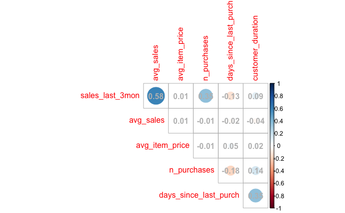

```r
# Visualization of correlations
df_grouped %>% select_if(is.numeric) %>%
  select(-customer_id) %>%
  cor() %>%
  corrplot(method = "circle", type = "upper", insig = "blank", diag = FALSE, addCoef.col = "grey")
```

Strong correlation between sales for the last 3 months and mean sales.

Assumptions of simple linear regression model

1.linear relationship between x and y 2.no measurement error in X (weak exogoeneity) 3. independence of errors expectation of errors is 0 4. constant variance of prediction errors (homoscedasticity) 5. normality of errors

```r
# Determine row to split on: split
split <- round(nrow(df_grouped) * 0.80)

# Create train
train <- df_grouped[1:split,]

# Create test
test <- df_grouped[(split + 1):nrow(df_grouped),]
```

```r
# Conduct regression on training set
sales_model  <- train %>%
  lm(
    sales_last_3mon ~ avg_sales + avg_item_price + n_purchases + days_since_last_purch + customer_duration,  # "as a function of"
    data = .
  )

# Show summary
sales_model %>% summary()
```

```
Call:
lm(formula = sales_last_3mon ~ avg_sales + avg_item_price + n_purchases +
    days_since_last_purch + customer_duration, data = .)

Residuals:
   Min     1Q Median     3Q    Max
-16325   -453    -30    121  91024

Coefficients:
                        Estimate Std. Error t value Pr(>|t|)
(Intercept)           -144.39686  136.38319  -1.059    0.290
avg_sales                1.00512    0.01571  63.996  < 2e-16 ***
avg_item_price           6.91091    4.95433   1.395    0.163
n_purchases             13.56750    0.39327  34.499  < 2e-16 ***
days_since_last_purch  -12.92085    2.43240  -5.312 1.19e-07 ***
customer_duration       15.62777    2.45906   6.355 2.50e-10 ***
---
Signif. codes:  0 ‘***’ 0.001 ‘**’ 0.01 ‘*’ 0.05 ‘.’ 0.1 ‘ ’ 1

Residual standard error: 2643 on 2305 degrees of freedom
Multiple R-squared:  0.706, Adjusted R-squared:  0.7053
F-statistic:  1107 on 5 and 2305 DF,  p-value: < 2.2e-16
```

We have quite a few significant variables. A decent r-squared and low-p-value for the model.

```r
# Predict on test set
preds <- predict(sales_model, test, type = "response")

# Compute errors
error <- preds - test$sales_last_3mon

# Calculate RMSE
sqrt(mean((preds - test$sales_last_3mon)^2))
```

```
[1] 6944.564
```

RMSE = 6944.564

We check VIF to avoid multicollinearity. There are no high VIF’s to worry about.

```r
car::vif(sales_model)
```

```
            avg_sales        avg_item_price           n_purchases days_since_last_purch
             1.002325              1.000821              1.086424              1.221420
    customer_duration
             1.207391
```

```r
# Calculating mean of future sales
mean(preds, na.rm = TRUE)
```

```
[1] 1143.173
```

We need to look for outliers or high-leverage observations. Will use the broom package to do this.

```r
sales_model %>%
  broom::augment() %>%
  arrange(desc(.hat)) %>%
  select(sales_last_3mon, n_purchases, avg_sales, .fitted, .resid, .hat) %>%
  head(10)
```

| sales_last_3mon | n_purchases | avg_sales | .fitted | .resid | .hat |
| --- | --- | --- | --- | --- | --- |
| 168469.60 | 1 | 168469.60 | 169215.0583 | -745.4583 | 0.99873829 |
| 464.90 | 1 | 464.90 | 3673.8490 | -3208.9490 | 0.74766080 |
| 64920.11 | 5052 | 12.85 | 69764.7692 | -4844.6592 | 0.53562909 |
| 61847.38 | 2717 | 22.76 | 38099.5008 | 23747.8792 | 0.14874362 |
| 19611.98 | 2555 | 7.68 | 35936.8729 | -16324.8929 | 0.13057032 |
| 7067.32 | 34 | 207.86 | 2009.8440 | 5057.4760 | 0.11411267 |
| 440.00 | 1 | 440.00 | 1136.5878 | -696.5878 | 0.04087424 |
| 4429.40 | 41 | 108.03 | 2321.6808 | 2107.7192 | 0.02711812 |
| 85.00 | 1 | 85.00 | 780.2418 | -695.2418 | 0.02577368 |
| 408.80 | 2 | 204.40 | 668.5885 | -259.7885 | 0.01903515 |

```r
NA
```

The leverage scores (.hat column) show the first 3 observations with highest leverage. This means that the observations are far from the mean of the explanatory variables.

```r
df_outliers_removed <- df_grouped %>%
  filter(customer_id != 16446 && customer_id != 16742 && customer_id != 14096)

head(df_outliers_removed)
```

| customer_id | sales_last_3mon | avg_sales | avg_item_price | n_purchases | days_since_last_purch | customer_duration |
| --- | --- | --- | --- | --- | --- | --- |
| 12347 | 1519.14 | 26.19 | 2.315517 | 58 | 2 | 39 |
| 12348 | 310.00 | 103.33 | 14.166667 | 3 | 75 | 75 |
| 12349 | 1757.55 | 24.08 | 8.289041 | 73 | 18 | 18 |
| 12352 | 944.23 | 20.09 | 6.617660 | 47 | 36 | 80 |
| 12356 | 58.35 | 29.17 | 11.850000 | 2 | 22 | 22 |
| 12357 | 6207.67 | 47.39 | 3.348626 | 131 | 33 | 33 |

```r
# To clean up the memory
rm(split, train, test, preds, error)
```

```r
# Determine row to split on: split
split <- round(nrow(df_outliers_removed) * 0.80)

# Create train
train <- df_outliers_removed[1:split,]

# Create test
test <- df_outliers_removed[(split + 1):nrow(df_outliers_removed),]


#check results
dim(train)
```

```
[1] 2311    7
```

```r
dim(train)/dim(df_outliers_removed) #proportions
```

```
[1] 0.7999308 1.0000000
```

```r
dim(test)
```

```
[1] 578   7
```

```r
dim(test)/dim(df_outliers_removed) # proportions
```

```
[1] 0.2000692 1.0000000
```

```r
# Conduct regression on training set - we will remove insignificant variable avg_item_price
sales_model_02  <- train %>%
  lm(
    sales_last_3mon ~ avg_sales + n_purchases + days_since_last_purch + customer_duration,  # "as a function of"
    data = .
  )

# Show summary
sales_model_02 %>% summary()
```

```
Call:
lm(formula = sales_last_3mon ~ avg_sales + n_purchases + days_since_last_purch +
    customer_duration, data = .)

Residuals:
   Min     1Q Median     3Q    Max
-16317   -455    -35    122  91026

Coefficients:
                        Estimate Std. Error t value Pr(>|t|)
(Intercept)           -121.43391  135.41381  -0.897     0.37
avg_sales                1.00514    0.01571  63.985  < 2e-16 ***
n_purchases             13.56287    0.39334  34.482  < 2e-16 ***
days_since_last_purch  -12.83834    2.43218  -5.279 1.42e-07 ***
customer_duration       15.60994    2.45953   6.347 2.64e-10 ***
---
Signif. codes:  0 ‘***’ 0.001 ‘**’ 0.01 ‘*’ 0.05 ‘.’ 0.1 ‘ ’ 1

Residual standard error: 2644 on 2306 degrees of freedom
Multiple R-squared:  0.7057,    Adjusted R-squared:  0.7052
F-statistic:  1383 on 4 and 2306 DF,  p-value: < 2.2e-16
```

```r
# Predict on test set
preds <- predict(sales_model_02, test, type = "response")

# Compute errors
error <- preds - test$sales_last_3mon

# Calculate RMSE
sqrt(mean((preds - test$sales_last_3mon)^2))
```

```
[1] 6920.299
```

This is great! We lowered the RMSE which provides better forecasts.

```r
cor(sales_model_02$fitted.values,train$sales_last_3mon) # Computes the correlation between the fitted values and the actual ones
```

```
[1] 0.8400801
```

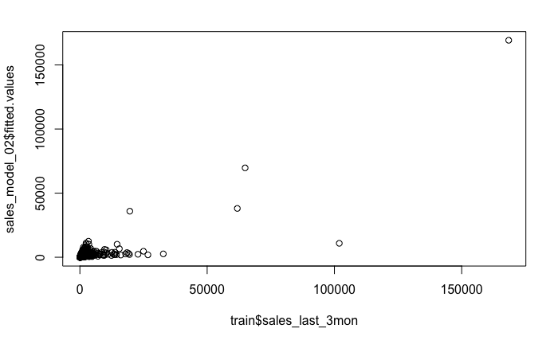

```r
plot(train$sales_last_3mon,sales_model_02$fitted.values) # Plot the fitted values vs. the actual ones
```

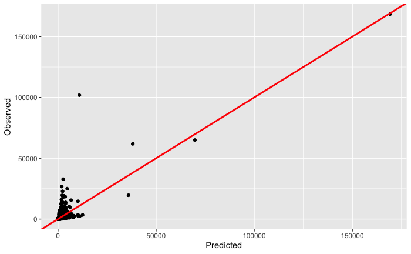

```r
data_mod <- data.frame(Predicted = predict(sales_model_02),
                       Observed = df_outliers_removed[c(1:2311),]$sales_last_3mon)

ggplot(data_mod,
       aes(x = Predicted,
           y = Observed)) +
  geom_point() +
  geom_abline(intercept = 0,
              slope = 1,
              color = "red",
              size = 1)
```

## Interpretation of the coefficients & learnings from the OLS model:

1. 71% of the variation in CLV can be explained by our independent variables. The remaining variation goes unexplained. The value of CLV would be -121 when all of my variables are 0 which doesn’t have a managerial interpretation.
2. Our model is significant with the low p-value
3. The effect of avg_sales and n_purchases and days_since_last_purch and customer_duration are statistically significant.
4. A one unit increase in avg_sales leads to 1 currency (british pounds) increase in CLV.
5. For each additional purchase order per customer increases CLV by 13 british pounds.
6. The longer the time since the customer’s last order (for every day), reduces CLV by 12 british pounds.
7. For each additional day when we acquire a new customer, we increase CLV by 15 british pounds.

## Customer Lifetime Value (CLV) Modeling with Bayesian Linear Regression

We will next try a Bayesian approach.

A Bayesian analysis answers the question, “Given these data, how likely is the difference?”

```r
library(rstanarm)
# Conduct regression
sales_bayes_model <- train %>%
  stan_glm(
    sales_last_3mon ~ avg_sales + n_purchases + days_since_last_purch + customer_duration,
    data = .,
    seed = 123
  )
# Show summary
sales_bayes_model %>% summary()
```

```
Model Info:
 function:     stan_glm
 family:       gaussian [identity]
 formula:      sales_last_3mon ~ avg_sales + n_purchases + days_since_last_purch +
       customer_duration
 algorithm:    sampling
 sample:       4000 (posterior sample size)
 priors:       see help('prior_summary')
 observations: 2311
 predictors:   5

Estimates:
                        mean   sd     10%    50%    90%
(Intercept)           -121.5  134.1 -293.3 -120.1   50.7
avg_sales                1.0    0.0    1.0    1.0    1.0
n_purchases             13.6    0.4   13.1   13.6   14.1
days_since_last_purch  -12.8    2.5  -16.0  -12.8   -9.6
customer_duration       15.6    2.5   12.5   15.6   18.8
sigma                 2644.7   39.1 2594.7 2645.0 2694.7

Fit Diagnostics:
           mean   sd     10%    50%    90%
mean_PPD 1161.6   78.8 1058.8 1161.6 1262.6

The mean_ppd is the sample average posterior predictive distribution of the outcome variable (for details see help('summary.stanreg')).

MCMC diagnostics
                      mcse Rhat n_eff
(Intercept)           1.7  1.0  6103
avg_sales             0.0  1.0  4920
n_purchases           0.0  1.0  4563
days_since_last_purch 0.0  1.0  4375
customer_duration     0.0  1.0  4466
sigma                 0.6  1.0  3895
mean_PPD              1.3  1.0  3919
log-posterior         0.0  1.0  1938

For each parameter, mcse is Monte Carlo standard error, n_eff is a crude measure of effective sample size, and Rhat is the potential scale reduction factor on split chains (at convergence Rhat=1).
```

## Final Summary

Key takeaways for CLV modeling and what can we suggest to both the sales and marketing teams: 1. We can use the CLV to allocate marketing resources between customers to maximize future profits. 2. We can prevent profitable customers from churning